# Identification of Important Genes in Leukemia Patients

## Introduction

- 7129 measurements of gene expressions
- 72 Leukemia patients
- ALL: Acute Lymphoblastic Leukemia
- AML: Acute Myeloid Leukemia

## Methods

## Tidying

[figure not shown]

## Data Wrangling

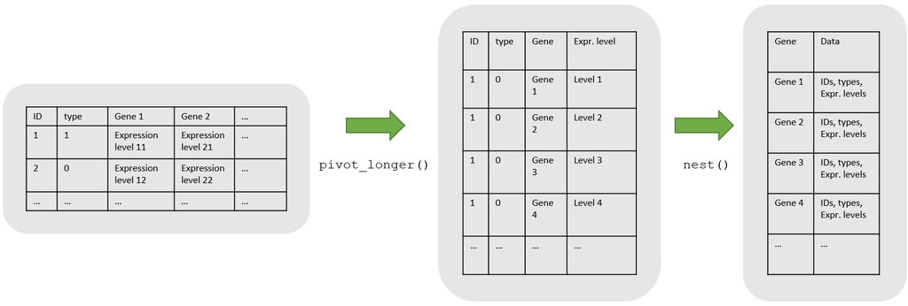

## Modelling

Logistic regression

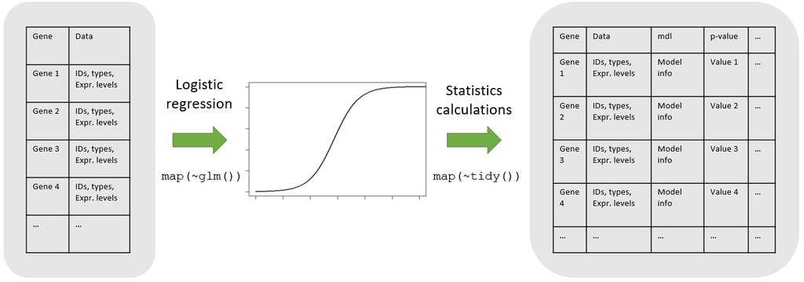

## Results

## Visualisations

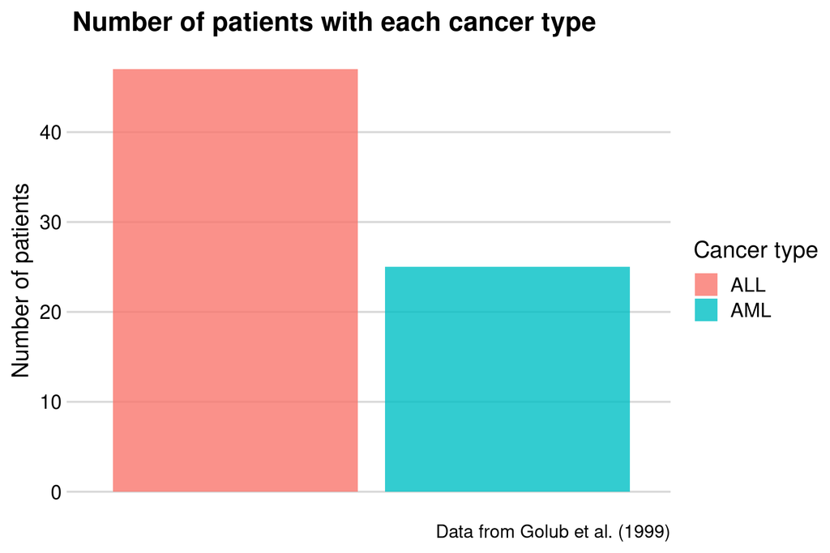

## Visualisations

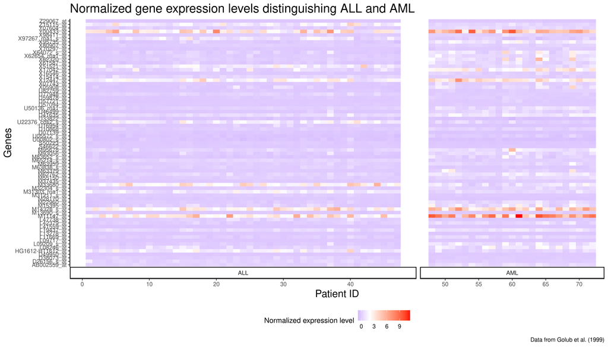

## Visualisations

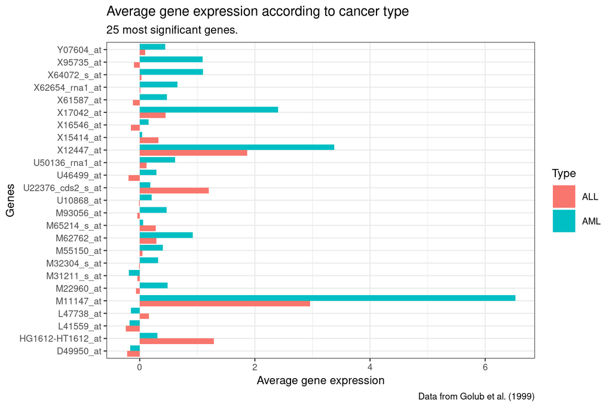

## Visualisations

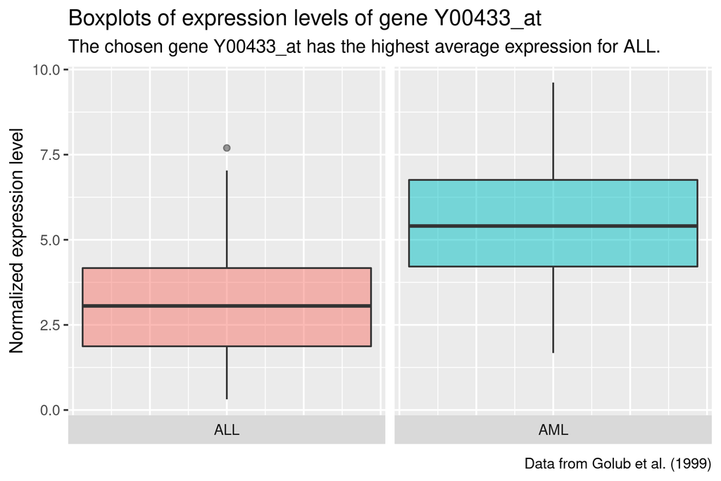

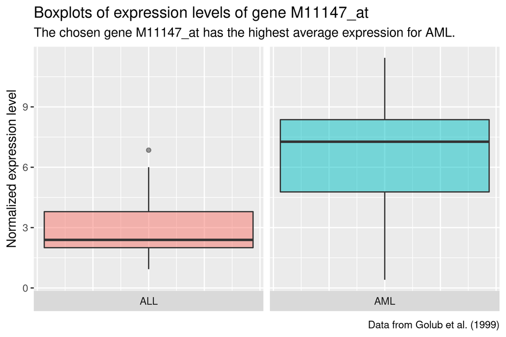

## Discussion

## Discussion

- Data transformation
  - Normalization vs. log2-fold

## Discussion

- Data transformation
- Modelling

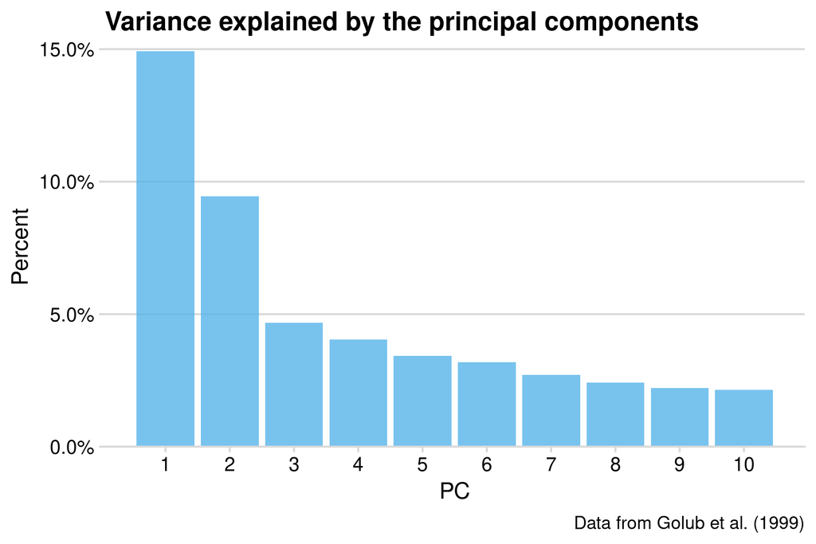

## Discussion

- Data transformation
- Modelling
- Plots

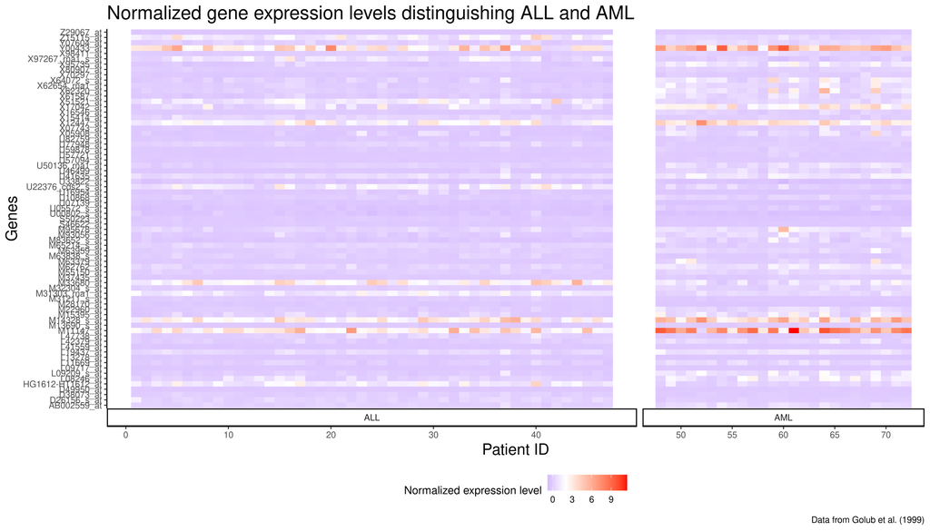

## Discussion

### Most important genes

- ALL: Y0043_at encodes GPX1
- AML: M11147_at endcodes the light subunit of ferritin protein

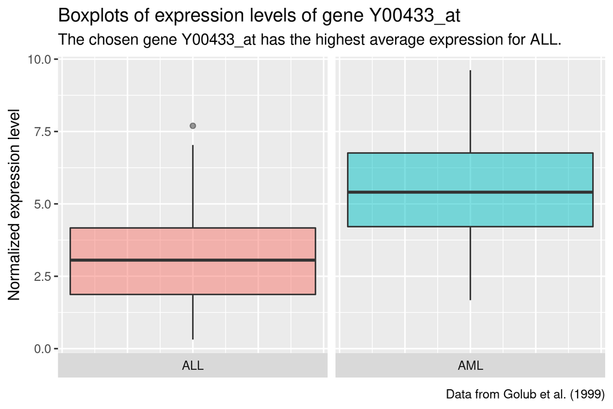

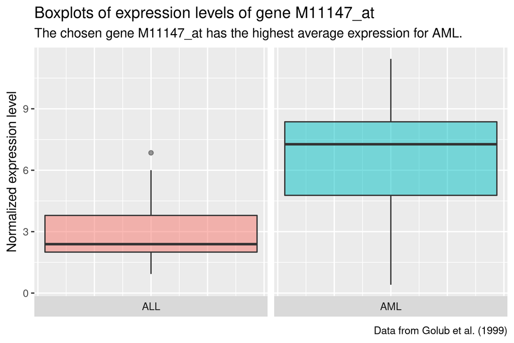

## Conclusion

- Data transformation
- PCA and K-means not suitable for our data
- Logistic regression and p-values used for deciding important genes
- We were able to convey our message through plots
- The most important genes for AML and ALL found in our project are also found to be involved in leukemia in literature

## References

The data set: https://github.com/ramhiser/datamicroarray

[1] Handschuh L, Kaźmierczak M, Milewski MC, et al. Gene expression profiling of acute myeloid leukemia samples from adult patients with AML-M1 and -M2 through boutique microarrays, real-time PCR and droplet digital PCR. Int J Oncol. 2018;52(3):656-678. doi: 10.3892/ijo.2017.4233

[2] Wei R, Qiu H, Xu J, Mo J, Liu Y, Gui Y, Huang G, Zhang S, Yao H, Huang X, Gan Z. Expression and prognostic potential of GPX1 in human cancers based on data mining. Ann Transl Med. 2020 Feb;8(4):124. doi: 10.21037/atm.2020.02.36. PMID: 32175417; PMCID: PMC7049064.

[3] Aulbert E, Schmidt CG. Ferritin–a tumor marker in myeloid leukemia. Cancer Detect Prev. 1985;8(1-2):297-302. PMID: 3864536.